# Análisis Tradicional sobre el Impacto Publicitario

Paula Zabaleta Eizaga

2025-06-09

# 1. Introducción

En este anexo se documenta el análisis realizado mediante el enfoque tradicional para evaluar la relación entre la inversión publicitaria y las ventas físicas. A diferencia del modelo econométrico utilizado en el cuerpo principal del TFG, este análisis se basa en herramientas descriptivas, gráficas y métricas básicas como la correlación, el ROI (retorno sobre la inversión) y el CPA (coste por adquisición).

Se ha utilizado la variable “impresiones_meta” como proxy de inversión, y se ha estimado el coste aplicando un valor medio de 3€ por cada mil impresiones (CPM), de acuerdo con benchmarks de plataformas como Meta Ads. La variable de resultado analizada es “ventas”, que representa las unidades vendidas en tienda física por semana.

```r
library(tidyverse)
library(lubridate)
library(scales)
library(readxl)
```

# 2. Lectura del dataset

```r
df <- read_excel("C:/Users/Pzabaletaeizaga/OneDrive/Documentos/cuarto carrera/TRABAJO DE FIN DE GRADO/dataset_tradicional_impresiones_meta.xlsx")

# Asegurar formato correcto
df$fecha <- as.Date(df$fecha)
df$impresiones <- as.numeric(df$impresiones)
df$ventas <- as.numeric(df$ventas)
df$coste_publicidad <- as.numeric(df$coste_publicidad)
```

# 3. Evolución temporal: Impresiones Vs. Ventas

Se grafica la evolución semanal de las impresiones publicitarias (línea verde discontinua) frente a las ventas físicas (línea azul) para detectar posibles coincidencias temporales entre inversión y resultados.

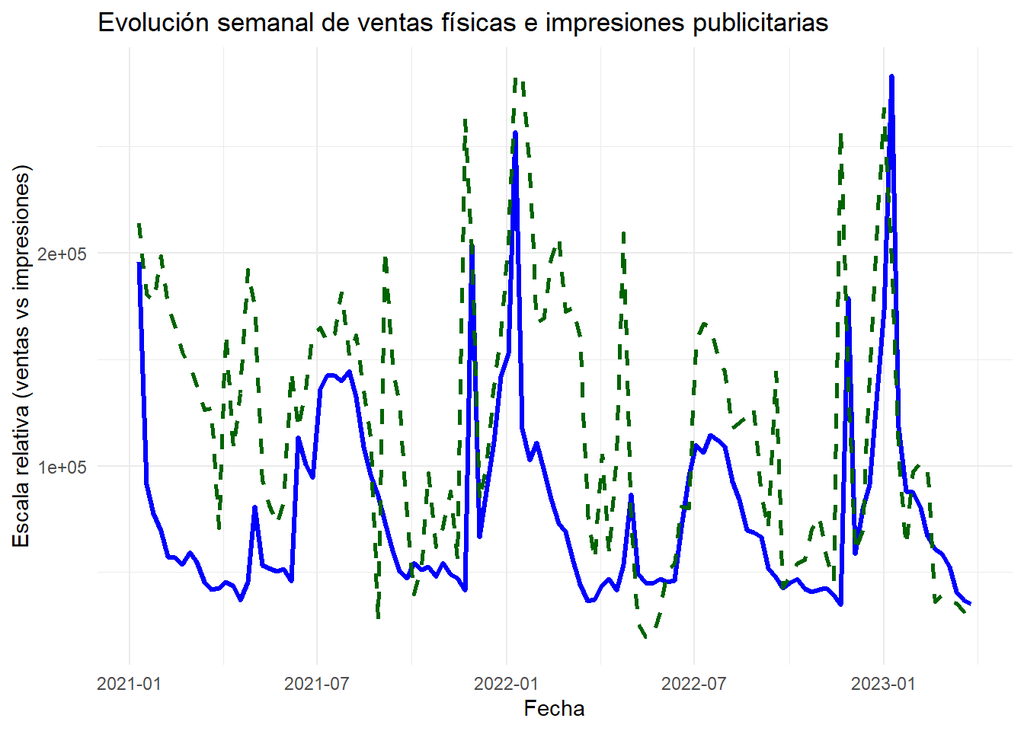

```r
ggplot(df, aes(x = fecha)) +
  geom_line(aes(y = ventas), color = "blue", size = 1.2) +
  geom_line(aes(y = impresiones * max(ventas) / max(impresiones)),
            color = "darkgreen", linetype = "dashed", size = 1) +
  labs(title = "Evolución semanal de ventas físicas e impresiones publicitarias",
       y = "Escala relativa (ventas vs impresiones)",
       x = "Fecha") +
  theme_minimal()
```

El gráfico sugiere que existe cierta correlación visual entre las campañas publicitarias y los picos de ventas físicas, especialmente en momentos de alta inversión. No obstante, la falta de inversión continua y la ausencia de control de otros factores impiden afirmar que la publicidad sea el principal causante de esos aumentos. Este tipo de análisis, característico del enfoque tradicional, puede ser útil como diagnóstico exploratorio, pero requiere ser complementado con herramientas más robustas si se busca optimizar presupuestos o atribuir impacto real a cada acción de marketing.

# 4. Correlación entre impresiones y ventas

Se calcula la correlación de Pearson para evaluar la relación lineal entre ambas variables.

```r
correlacion <- cor(df$ventas, df$impresiones, use = "complete.obs")
paste("Correlación entre ventas e impresiones:", round(correlacion, 3))
```

```
## [1] "Correlación entre ventas e impresiones: 0.55"
```

En este caso, se obtuvo un valor de correlación de Pearson de aproximadamente 0.55 entre el número de impresiones publicitarias y las ventas físicas semanales. Este valor indica que existe una relación lineal moderadamente positiva entre ambas variables: en general, cuando aumentan las impresiones, también tienden a aumentar las ventas, y viceversa.

Sin embargo, es importante matizar que este resultado no implica necesariamente que la publicidad sea la causa directa de dicho incremento en ventas. La correlación estadística únicamente refleja que ambas variables se mueven de forma similar, pero no demuestra que una provoque la otra. Esta es una de las principales limitaciones del enfoque tradicional basado en análisis descriptivo: no controla por otros factores que pueden estar influyendo al mismo tiempo, como descuentos, notoriedad de marca, efectos estacionales o cambios en el comportamiento del consumidor.

Además, la publicidad puede tener efectos retardados, es decir, no producir impacto en la misma semana en la que se activa, sino más adelante—, y eso no se capta en un análisis de correlación simple. Por todo ello, aunque el valor de 0.55 sugiere que las impresiones y las ventas están relacionadas, se requiere un enfoque más riguroso (como el modelo econométrico utilizado posteriormente) para poder afirmar que la publicidad tiene un efecto causal y cuantificable sobre las ventas.

## 4.1 Modelo de Regresión Tradicional

A continuación, se estima un modelo de regresión lineal simple que permite cuantificar el impacto de las impresiones publicitarias y el coste en publicidad sobre las ventas físicas semanales. Este tipo de modelo, aunque básico, ofrece una primera aproximación cuantitativa útil en entornos donde el análisis se basa en métricas operativas accesibles.

```r
# Estimación del modelo tradicional básico
modelo_tradicional <- lm(ventas ~ impresiones + coste_publicidad, data = df)

# Ver resumen del modelo
summary(modelo_tradicional)
```

```
##
## Call:
## lm(formula = ventas ~ impresiones + coste_publicidad, data = df)
##
## Residuals:
##    Min     1Q Median     3Q    Max
## -97441 -23177  -5090  17864 174935
##
## Coefficients: (1 not defined because of singularities)
##                   Estimate Std. Error t value Pr(>|t|)
## (Intercept)      3.084e+04  7.646e+03   4.033 9.99e-05 ***
## impresiones      2.840e-03  4.036e-04   7.037 1.56e-10 ***
## coste_publicidad        NA         NA      NA       NA
## ---
## Signif. codes:  0 '***' 0.001 '**' 0.01 '*' 0.05 '.' 0.1 ' ' 1
##
## Residual standard error: 37840 on 114 degrees of freedom
## Multiple R-squared:  0.3028, Adjusted R-squared:  0.2967
## F-statistic: 49.52 on 1 and 114 DF,  p-value: 1.563e-10
```

Los resultados del modelo muestran que las impresiones publicitarias tienen un efecto positivo y significativo sobre las ventas físicas semanales (p < 0.001), con un coeficiente de 0.00284. Esto implica que, en promedio, cada impresión adicional se asocia con un aumento de 0.00284 unidades monetarias en ventas. La variable `coste_publicidad` fue excluida automáticamente por colinealidad perfecta, lo que indica que no aporta información adicional respecto a las impresiones.

El modelo presenta un R² ajustado de 0.297, lo que significa que explica aproximadamente el 30% de la variabilidad en las ventas. Si bien este nivel de ajuste es limitado, resulta razonable para un modelo básico con solo una variable explicativa real. Esta estimación constituye una primera aproximación útil para cuantificar el efecto publicitario desde una perspectiva tradicional.

# 5. Cálculo del ROI (Retorno sobre la Inversión)

```r
df <- df %>%
  mutate(ROI = (ventas - coste_publicidad) / coste_publicidad)
ROI <- (sum(df$ventas) - sum(df$coste_publicidad)) / sum(df$coste_publicidad)
ROI
```

```
## [1] 0.5574789
```

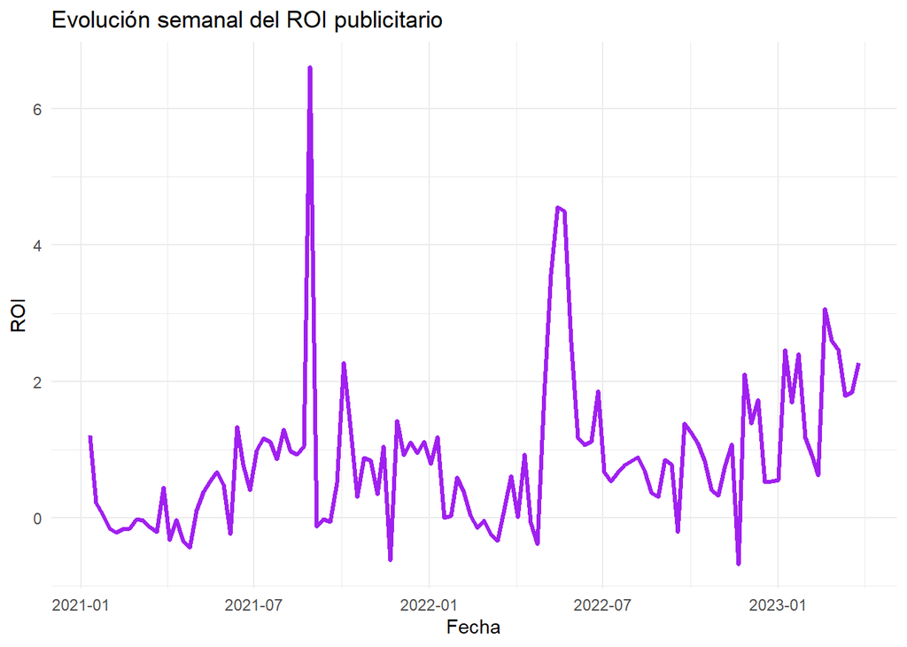

```r
ggplot(df, aes(x = fecha, y = ROI)) +
  geom_line(color = "purple", linewidth = 1.2) +
  labs(title = "Evolución semanal del ROI publicitario",
       y = "ROI", x = "Fecha") +
  theme_minimal()
```

El cálculo del ROI medio para el periodo analizado arroja un valor de aproximadamente 0.56, lo que implica que por cada euro invertido en publicidad, se han generado 1.56 euros en ventas (recuperando la inversión y obteniendo un 56% adicional). Este valor, aunque moderado, indica que la inversión publicitaria ha sido en general rentable.

El gráfico muestra la evolución semanal del ROI publicitario a lo largo del periodo 2021–2023, calculado como la relación entre el beneficio incremental estimado y el coste publicitario aproximado (derivado de las impresiones y un CPM medio de 3€). Se observa una alta variabilidad en los valores, con tramos cercanos a cero, picos pronunciados que superan el 6 y etapas de rendimiento más sostenido.

Los picos más destacados, como los de mediados de 2021 y mediados de 2022, reflejan semanas con gran eficiencia publicitaria, probablemente asociadas a campañas puntuales de éxito o periodos estacionales con alta conversión. En cambio, otras semanas muestran retornos bajos o incluso negativos, lo que sugiere inversiones menos efectivas o mal alineadas con la demanda real.

# 6. Cálculo del CPA (Coste por Adquisición)

```r
df <- df %>%
  mutate(CPA = coste_publicidad / ventas)
CPA <- sum(df$coste_publicidad) / sum(df$ventas)
CPA
```

```
## [1] 0.6420633
```

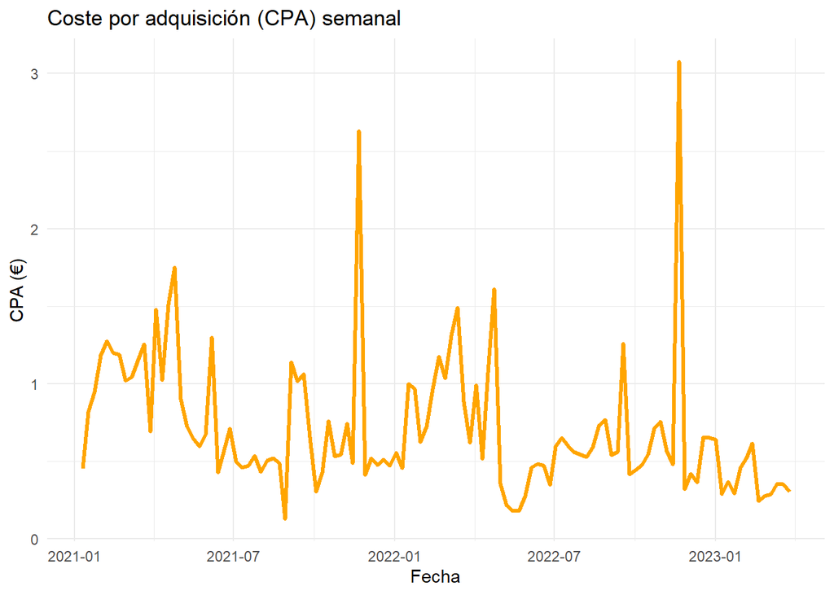

```r
ggplot(df, aes(x = fecha, y = CPA)) +
  geom_line(color = "orange", linewidth = 1.2) +
  labs(title = "Coste por adquisición (CPA) semanal",
       y = "CPA (€)", x = "Fecha") +
  theme_minimal()
```

El cálculo del CPA (Coste Por Adquisición) resulta en un valor de 0.64, lo que indica que, en promedio, se han invertido 0.64 euros en publicidad por cada euro generado en ventas. Este indicador complementa al ROI y permite evaluar la eficiencia del gasto desde una perspectiva de coste unitario. Un CPA inferior a 1 es generalmente considerado aceptable, ya que implica que el coste de atraer o convertir clientes es inferior al valor que estos generan.

El gráfico representa la evolución del coste por adquisición (CPA) a lo largo del periodo semanal entre 2021 y 2023. El CPA se ha calculado como el cociente entre el coste publicitario estimado y las ventas físicas semanales, ofreciendo una medida directa del coste asociado a generar una unidad vendida.

A lo largo del tiempo, se aprecia cierta tendencia a la estabilización del CPA, especialmente en la parte final del periodo, lo que podría reflejar una mejor planificación o una mayor alineación entre las campañas publicitarias y la respuesta del consumidor. En cualquier caso, la variabilidad observada subraya la necesidad de complementar este análisis con técnicas más rigurosas si se desea optimizar el presupuesto de manera efectiva.

# 7. Conclusiones

El análisis realizado desde el enfoque tradicional ha permitido explorar de forma descriptiva la relación entre inversión publicitaria y ventas físicas mediante herramientas simples como la correlación, gráficos temporales y métricas operativas (ROI y CPA).

A través de la visualización conjunta de impresiones y ventas, se han detectado algunas coincidencias temporales entre campañas publicitarias y picos de ventas, especialmente en periodos promocionales. La correlación de 0.55 entre ambas variables indica una relación positiva moderada, aunque no suficiente para establecer causalidad.

En cuanto a la rentabilidad, el ROI medio obtenido fue de 0.56, lo que implica que por cada euro invertido en publicidad se generaron 1.56 euros en ventas. Aunque este valor refleja una inversión globalmente rentable, la evolución semanal del ROI mostró una alta variabilidad, con semanas de alto rendimiento intercaladas con otras menos eficientes. Por su parte, el CPA medio fue de 0.64, lo que indica que, en promedio, se necesitaron 0.64 euros de inversión publicitaria por cada euro generado en ventas.

En conjunto, este enfoque permite obtener una primera aproximación al rendimiento de la inversión, pero carece del control necesario sobre factores externos y dinámicas temporales. Por tanto, sus conclusiones deben interpretarse con cautela. Aun así, sirve como base útil para comparar con metodologías más robustas, como el modelo de Marketing Mix Modeling que se presenta en los siguientes apartados.